# Análise de Qualidade de Vinhos Tintos por Lucas Santos

# Carregamento dos dados

```
##   X fixed.acidity volatile.acidity citric.acid residual.sugar chlorides
## 1 1           7.4             0.70        0.00            1.9     0.076
## 2 2           7.8             0.88        0.00            2.6     0.098
## 3 3           7.8             0.76        0.04            2.3     0.092
## 4 4          11.2             0.28        0.56            1.9     0.075
## 5 5           7.4             0.70        0.00            1.9     0.076
## 6 6           7.4             0.66        0.00            1.8     0.075
##   free.sulfur.dioxide total.sulfur.dioxide density   pH sulphates alcohol
## 1                  11                   34  0.9978 3.51      0.56     9.4
## 2                  25                   67  0.9968 3.20      0.68     9.8
## 3                  15                   54  0.9970 3.26      0.65     9.8
## 4                  17                   60  0.9980 3.16      0.58     9.8
## 5                  11                   34  0.9978 3.51      0.56     9.4
## 6                  13                   40  0.9978 3.51      0.56     9.4
##   quality
## 1       5
## 2       5
## 3       5
## 4       6
## 5       5
## 6       5
```

```
##  fixed.acidity   volatile.acidity  citric.acid    residual.sugar
##  Min.   : 4.60   Min.   :0.1200   Min.   :0.000   Min.   : 0.900
##  1st Qu.: 7.10   1st Qu.:0.3900   1st Qu.:0.090   1st Qu.: 1.900
##  Median : 7.90   Median :0.5200   Median :0.260   Median : 2.200
##  Mean   : 8.32   Mean   :0.5278   Mean   :0.271   Mean   : 2.539
##  3rd Qu.: 9.20   3rd Qu.:0.6400   3rd Qu.:0.420   3rd Qu.: 2.600
##  Max.   :15.90   Max.   :1.5800   Max.   :1.000   Max.   :15.500
##    chlorides       free.sulfur.dioxide total.sulfur.dioxide
##  Min.   :0.01200   Min.   : 1.00       Min.   :  6.00
##  1st Qu.:0.07000   1st Qu.: 7.00       1st Qu.: 22.00
##  Median :0.07900   Median :14.00       Median : 38.00
##  Mean   :0.08747   Mean   :15.87       Mean   : 46.47
##  3rd Qu.:0.09000   3rd Qu.:21.00       3rd Qu.: 62.00
##  Max.   :0.61100   Max.   :72.00       Max.   :289.00
##     density             pH          sulphates         alcohol
##  Min.   :0.9901   Min.   :2.740   Min.   :0.3300   Min.   : 8.40
##  1st Qu.:0.9956   1st Qu.:3.210   1st Qu.:0.5500   1st Qu.: 9.50
##  Median :0.9968   Median :3.310   Median :0.6200   Median :10.20
##  Mean   :0.9967   Mean   :3.311   Mean   :0.6581   Mean   :10.42
##  3rd Qu.:0.9978   3rd Qu.:3.400   3rd Qu.:0.7300   3rd Qu.:11.10
##  Max.   :1.0037   Max.   :4.010   Max.   :2.0000   Max.   :14.90
##     quality
##  Min.   :3.000
##  1st Qu.:5.000
##  Median :6.000
##  Mean   :5.636
##  3rd Qu.:6.000
##  Max.   :8.000
```

# Seção de Gráficos Univariados

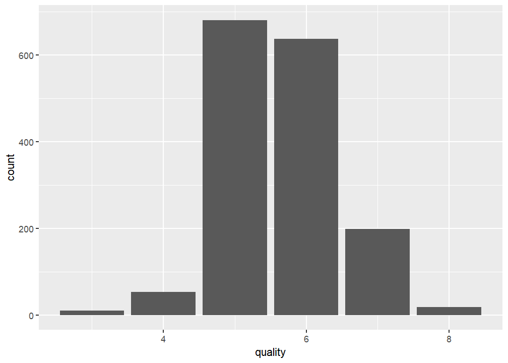

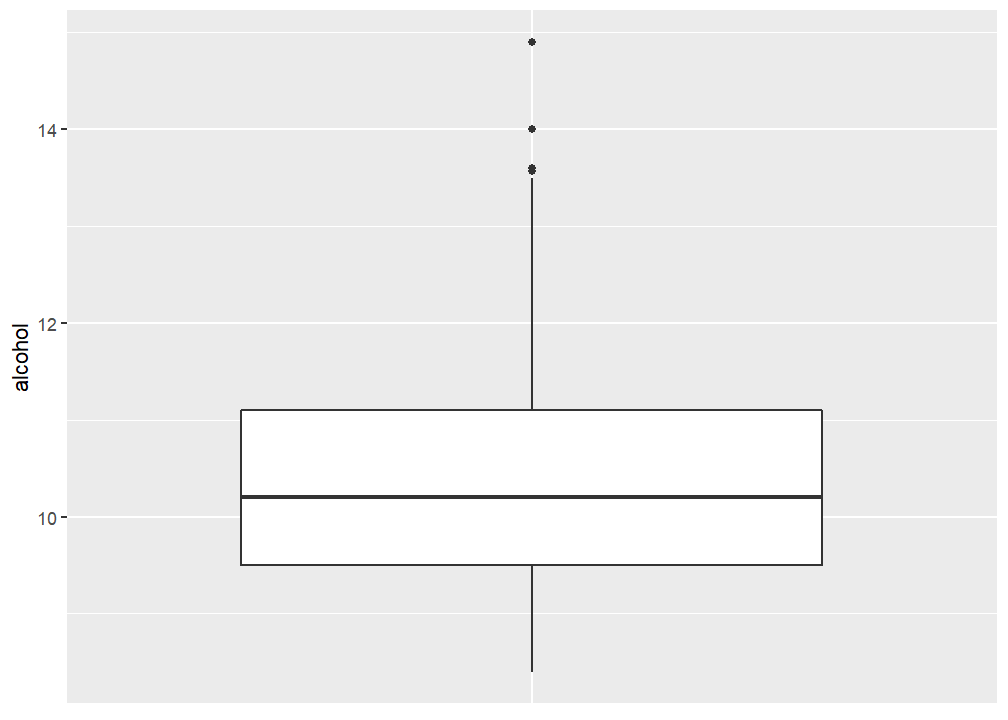

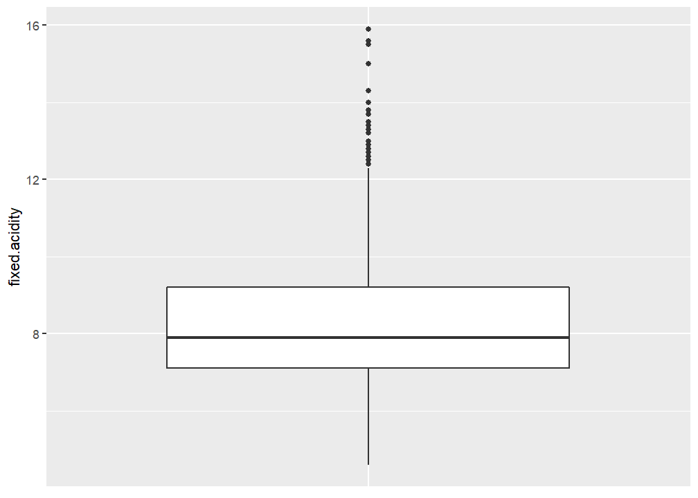

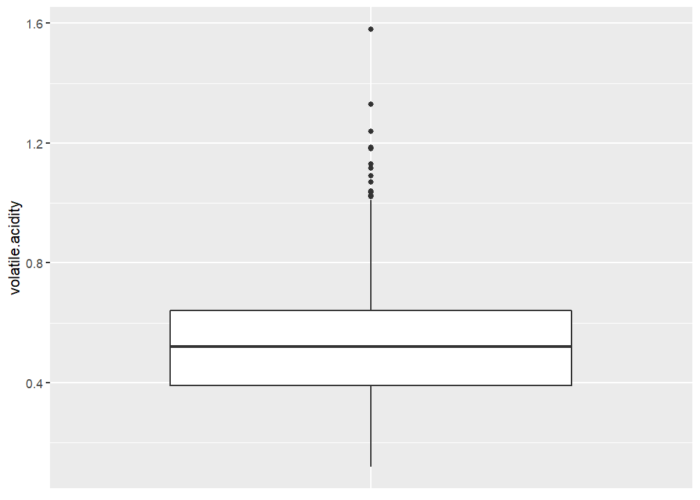

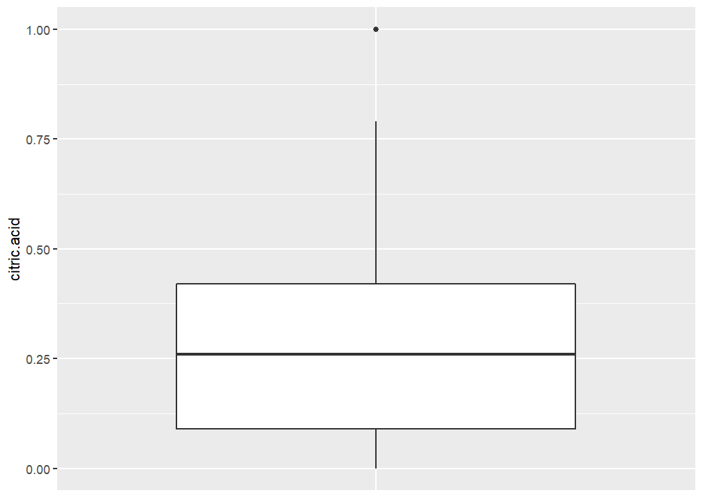

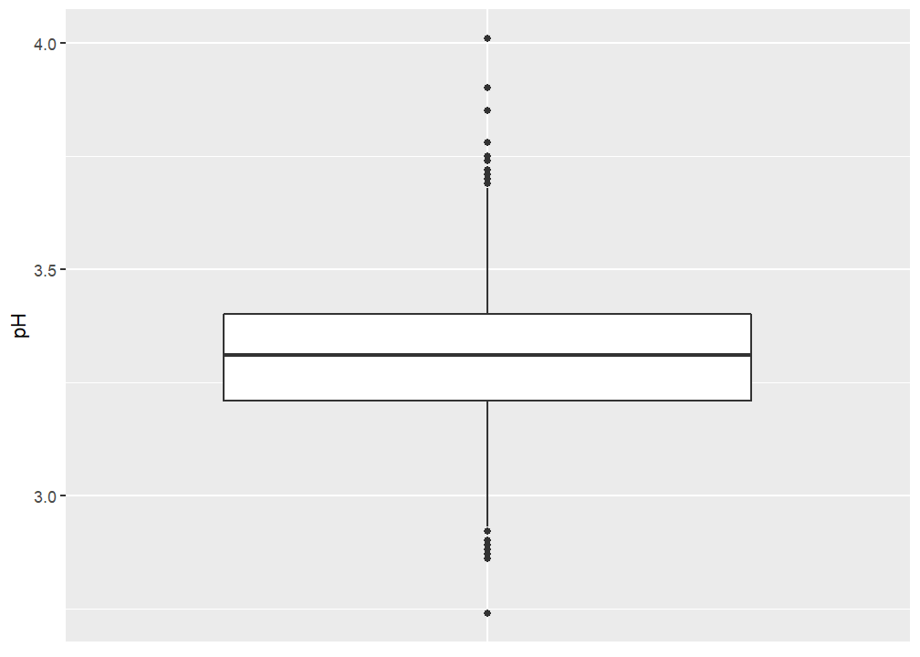

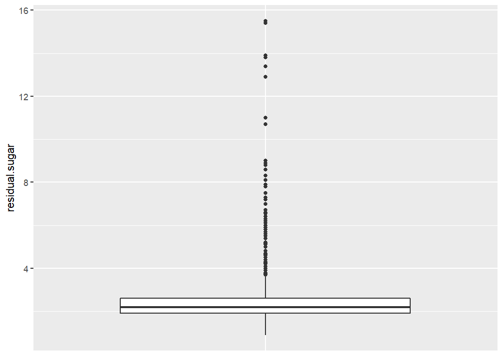

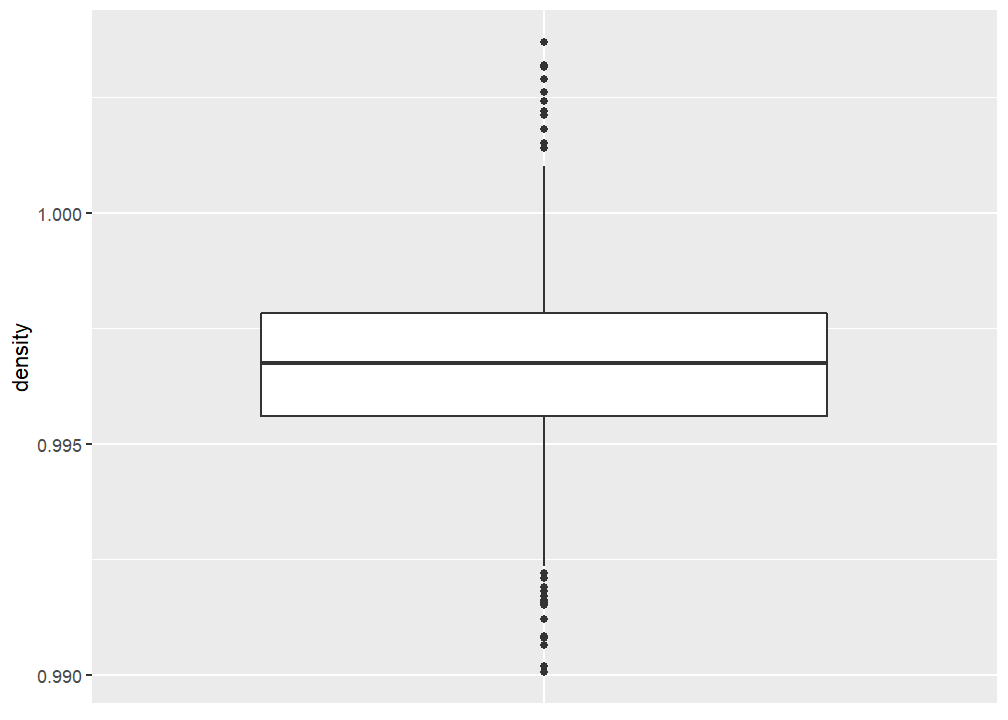

# Análise Univariada

### Qual é a estrutura do conjunto de dados?

O conjunto de dados é formado por 12 variáveis numéricas, elas são: fixed.acidity, volatile.acidity, citric.acid, residual.sugar, chlorides, free.sulfur.dioxide, total.sulfur.dioxide, density, pH, sulphates, alcohol e quality

### Quais são os principais atributos de interesse deste conjunto de dados?

O principal atributo de interesse destes dados é o quality, que é a nota dada devida a qualidade do vinho. Os atributos mais relevantes para isso são os relacionados ao sabor, como o teor alcoolico, a acidez, o douçor e a densidade.

### Quais outros atributos você acha que podem lhe auxiliar na investigação destes atributos de interesse?

Os principais atributos de interesse são aqueles relacionado a acidez; fixed.acidity, volatile.acidity, citric.acid e pH além dos atributos residual.sugar, density e alcohol.

### Você criou novas variáveis a partir dos atributos existentes no conjunto de dados?

Novas variáveis não foram criadas.

### Dos atributos investigados, distribuições incomuns foram encontradas? Você aplicou operações nos dados para limpá-los, ajustá-los ou mudar a forma dos dados? Se sim, por quê?

Como essa é uma análise exploratória dos dados nenhuma operação de limpeza ou ajuste dos dados foi realizada, porém para fazer classificações ou predições essas operações seriam feitas.

# Seção de Gráficos Bivariados

[figure not shown]

```
##                      fixed.acidity volatile.acidity citric.acid
## fixed.acidity                 1.00            -0.26        0.67
## volatile.acidity             -0.26             1.00       -0.55
## citric.acid                   0.67            -0.55        1.00
## residual.sugar                0.11             0.00        0.14
## chlorides                     0.09             0.06        0.20
## free.sulfur.dioxide          -0.15            -0.01       -0.06
## total.sulfur.dioxide         -0.11             0.08        0.04
## density                       0.67             0.02        0.36
## pH                           -0.68             0.23       -0.54
## sulphates                     0.18            -0.26        0.31
## alcohol                      -0.06            -0.20        0.11
## quality                       0.12            -0.39        0.23
##                      residual.sugar chlorides free.sulfur.dioxide
## fixed.acidity                  0.11      0.09               -0.15
## volatile.acidity               0.00      0.06               -0.01
## citric.acid                    0.14      0.20               -0.06
## residual.sugar                 1.00      0.06                0.19
## chlorides                      0.06      1.00                0.01
## free.sulfur.dioxide            0.19      0.01                1.00
## total.sulfur.dioxide           0.20      0.05                0.67
## density                        0.36      0.20               -0.02
## pH                            -0.09     -0.27                0.07
## sulphates                      0.01      0.37                0.05
## alcohol                        0.04     -0.22               -0.07
## quality                        0.01     -0.13               -0.05
##                      total.sulfur.dioxide density    pH sulphates alcohol
## fixed.acidity                       -0.11    0.67 -0.68      0.18   -0.06
## volatile.acidity                     0.08    0.02  0.23     -0.26   -0.20
## citric.acid                          0.04    0.36 -0.54      0.31    0.11
## residual.sugar                       0.20    0.36 -0.09      0.01    0.04
## chlorides                            0.05    0.20 -0.27      0.37   -0.22
## free.sulfur.dioxide                  0.67   -0.02  0.07      0.05   -0.07
## total.sulfur.dioxide                 1.00    0.07 -0.07      0.04   -0.21
## density                              0.07    1.00 -0.34      0.15   -0.50
## pH                                  -0.07   -0.34  1.00     -0.20    0.21
## sulphates                            0.04    0.15 -0.20      1.00    0.09
## alcohol                             -0.21   -0.50  0.21      0.09    1.00
## quality                             -0.19   -0.17 -0.06      0.25    0.48
##                      quality
## fixed.acidity           0.12
## volatile.acidity       -0.39
## citric.acid             0.23
## residual.sugar          0.01
## chlorides              -0.13
## free.sulfur.dioxide    -0.05
## total.sulfur.dioxide   -0.19
## density                -0.17
## pH                     -0.06
## sulphates               0.25
## alcohol                 0.48
## quality                 1.00
```

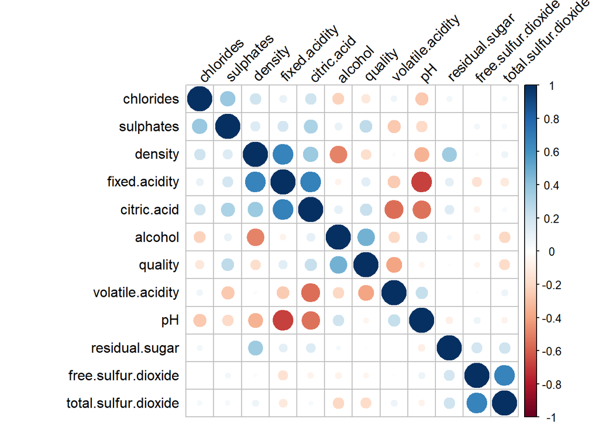

# Análise Bivariada

### Discuta sobre alguns dos relacionamentos observados nesta parte da investigação. Como os atributos de interesse variaram no conjunto de dados?

Os atributos de interesse que mais se relacionam com a qualidade do vinho são:

AS carceterisitcas de interesse possuem distribuições do tipo assimétrica e normal. Os que possuem distribuição não normal ela é do tipo assimétrica positiva.

### Você observou algum relacionamento interessante entre os outros atributos (os que não são de interesse)?

Chlorides possui uma correlação de 0,37 com sulphates. E free.sulfur.dioxide possui uma correlação de 0.67 com total.sulfur.dioxide

### Qual foi o relacionamento mais forte encontrado?

O relacionamento encontrado mais forte é o de fixed.acidity com pH. Eles possuem uma correlação de -0,68.

# Seção de Gráficos Multivariados

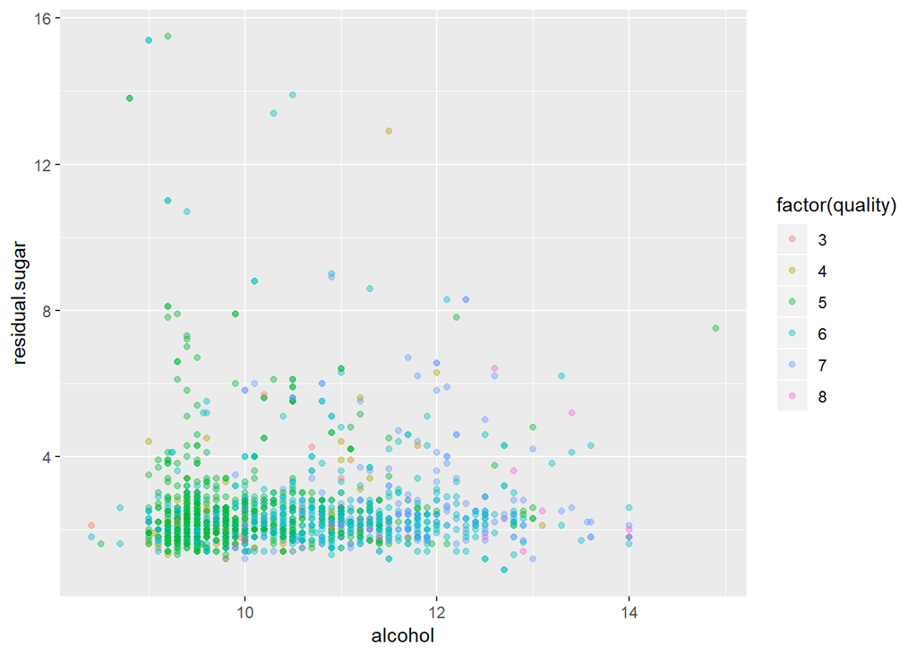

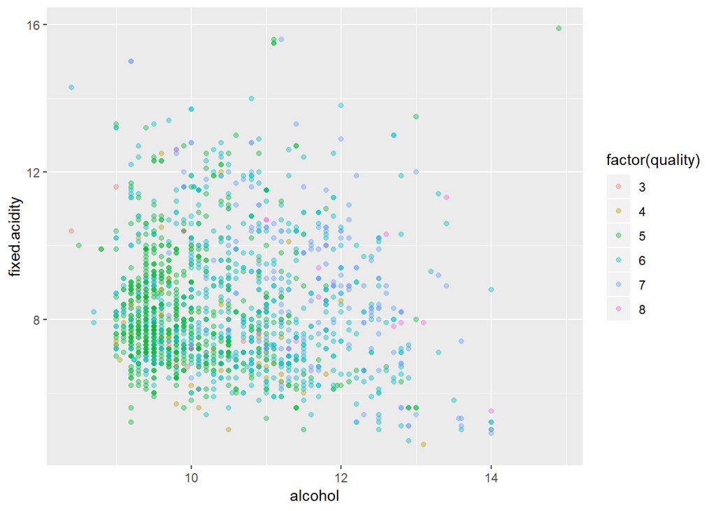

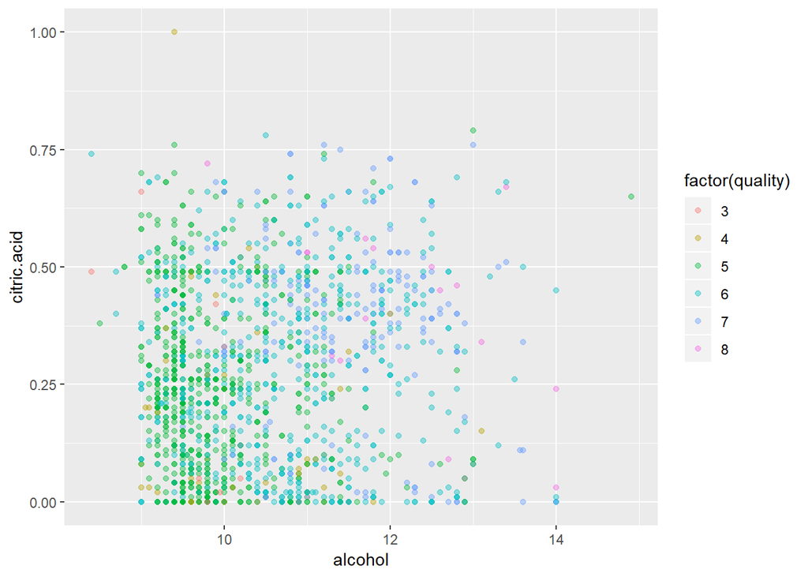

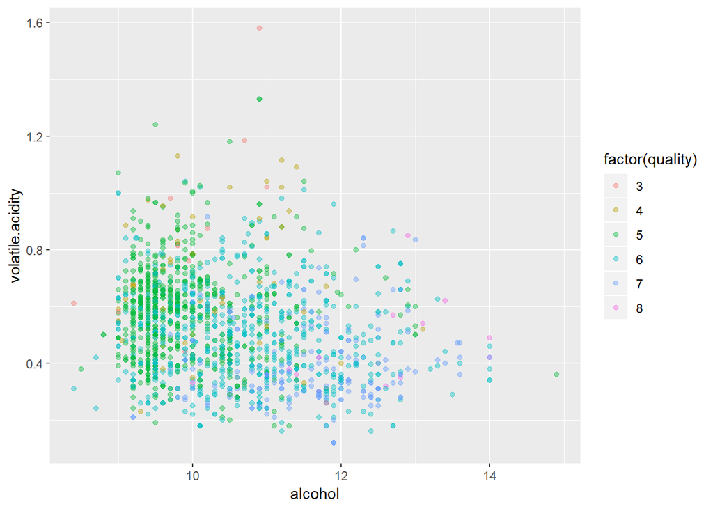

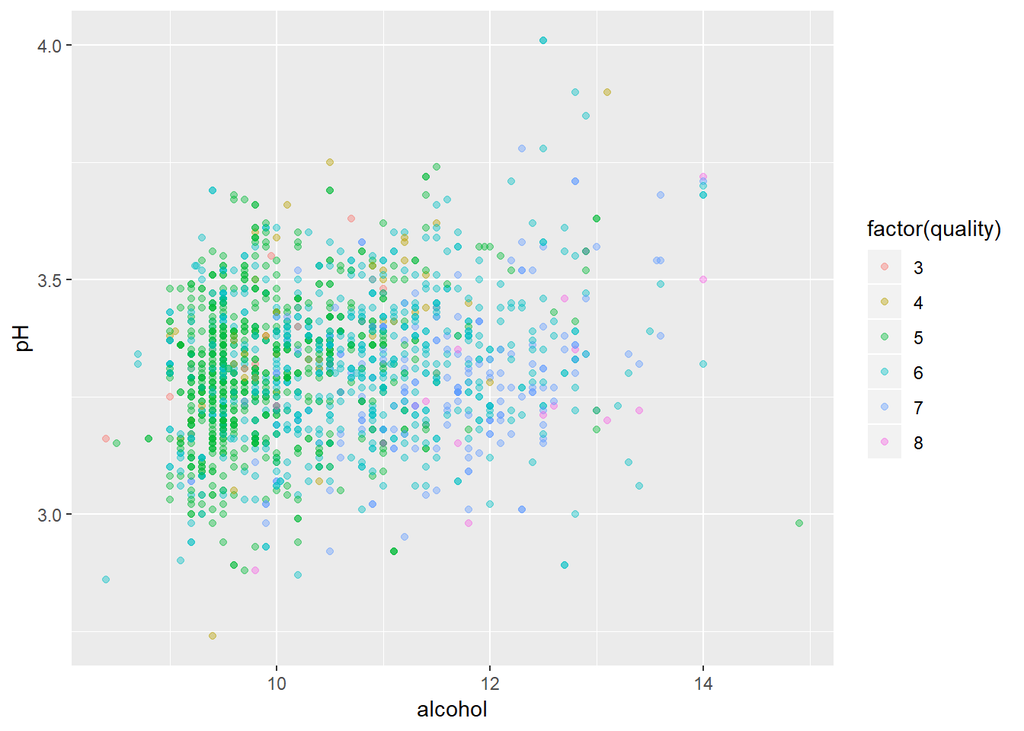

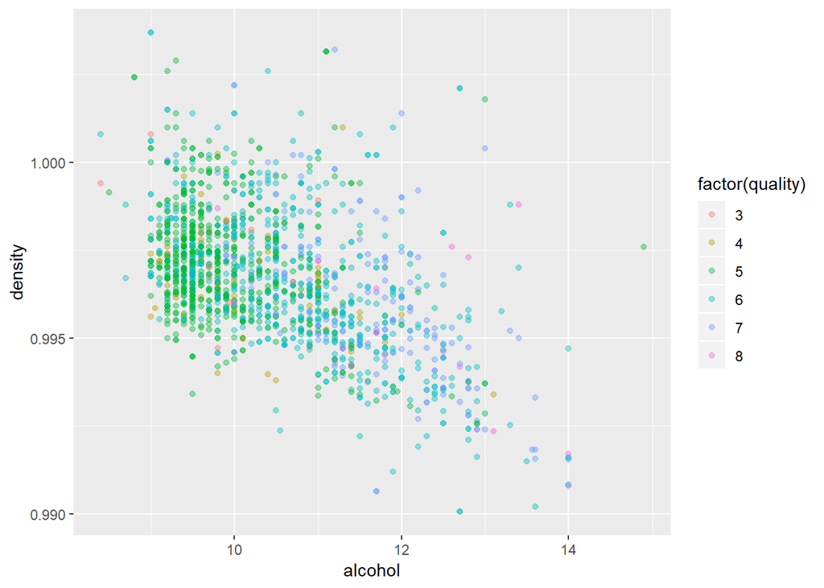

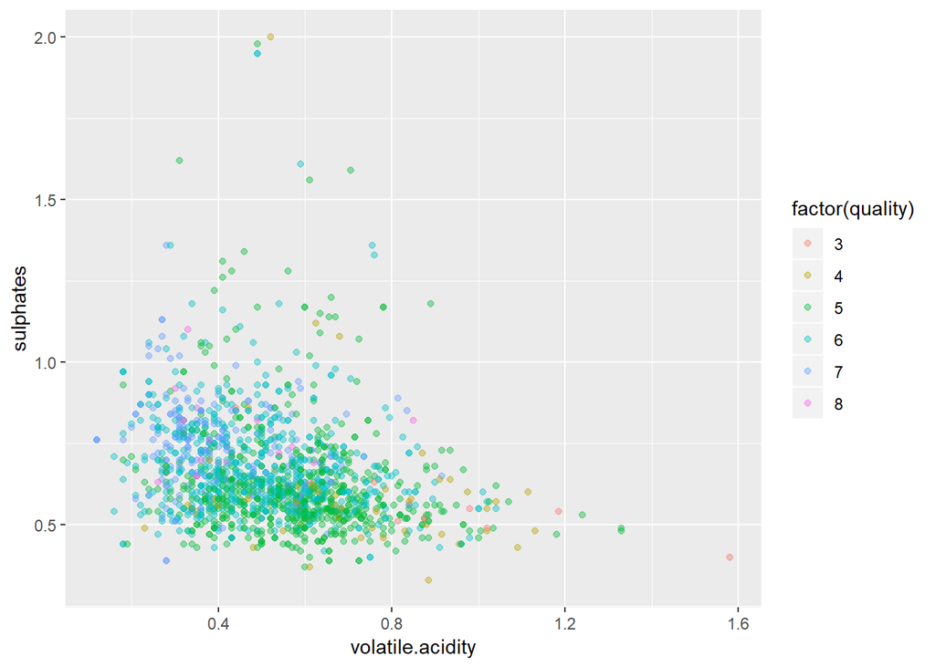

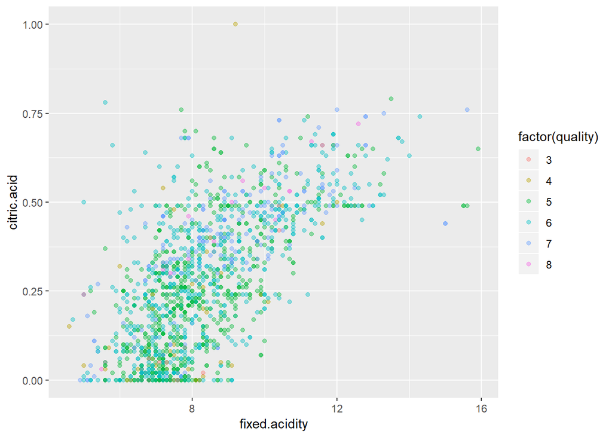

# Análise Multivariada

### Discuta sobre os relacionamentos observados nesta parte da investigação. Quais atributos que fortaleceram os demais na observação das variáveis de interesse?

A fixed.acidity, citric.acid são linearmente e diretamente proporciais porém não há uma relação clara com a qualidade do vinho.

Residual.sugar e alcohol, apesar da relação entre eles ser pouco significativa quanto maior o teor alcoolico e na faixa entre 2 g/dm³ e 4 g/dm³ os vinhos são melhores.

Outros atributos também se correlacionam porém são inversamente proporcionais como alcohol e density entretanto a qualidade do vinho cresce a medida que a densidade diminui e o teor de álcool cresce.

### Interações surpreendentes e/ou interessantes foram encontradas entre os atributos?

Alguns atributos não possuem relações tão claras como é o caso do alcohol e citric.acid, fixed.acidity e alcohol, volatile.acidity e alcohol e pH e alcohol em que os dados são dispersos mesmo levando em consideração a qualidade.

# Gráficos Finais e Sumário

### Primeiro Gráfico

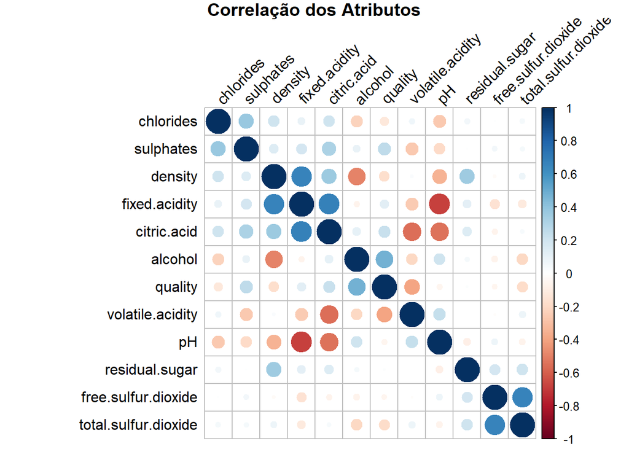

### Descrição do Primeiro Gráfico

Este gráfico mostra a correlação entre os atributos do conjunto de dados de maneira bem visual e intuitiva. Nele é possível visualizar rapidamente quais as caracteristicas dos vinhos que mais se correlatam.

### Segundo Gráfico

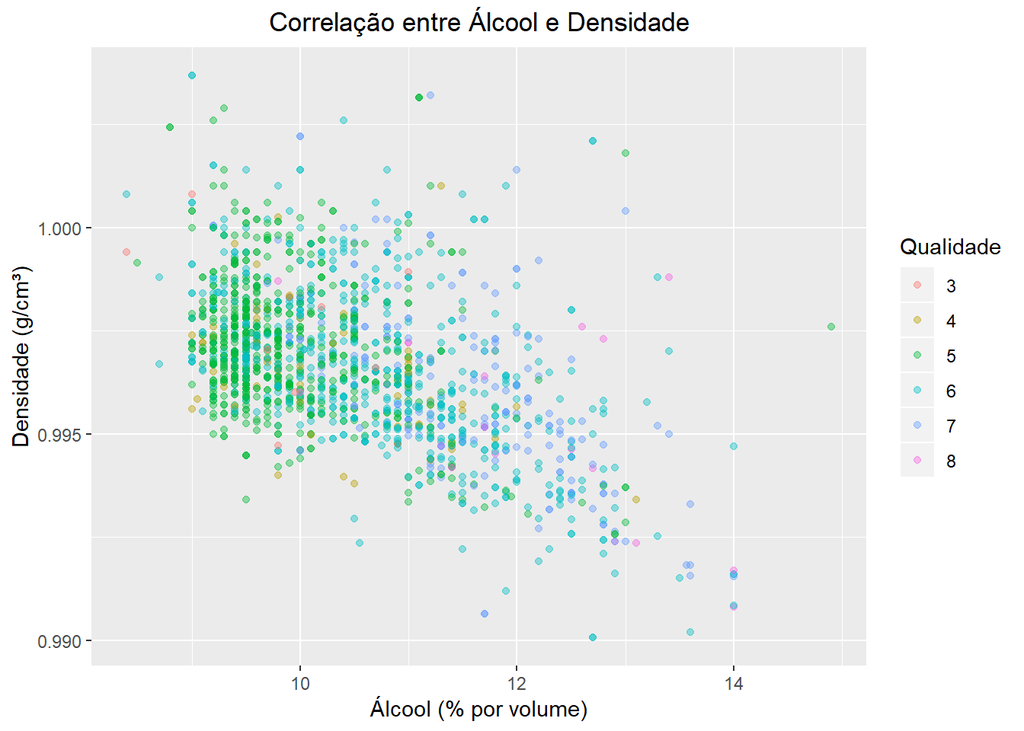

### Descrição do Segundo Gráfico

Esse gráfico mostra a correlação entre Densidade (density) e Álcool (alcohol) levando em consideração a qualidade do vinho (quality). O teor alcoolico é um dos atributos que mais possui correlação com a qualidade do vinho, e a densidade é o atributo que mais correlata com o teor alcolico.

Como pode ser visto no gráfico, é uma relação que possui uma lineraidade e os vinhos melhores possuem um teor alcoolico entre 11% e 14% e uma densidade entre 0,9925 g/cm³ e 1 g/cm³.

### Terceiro Gráfico

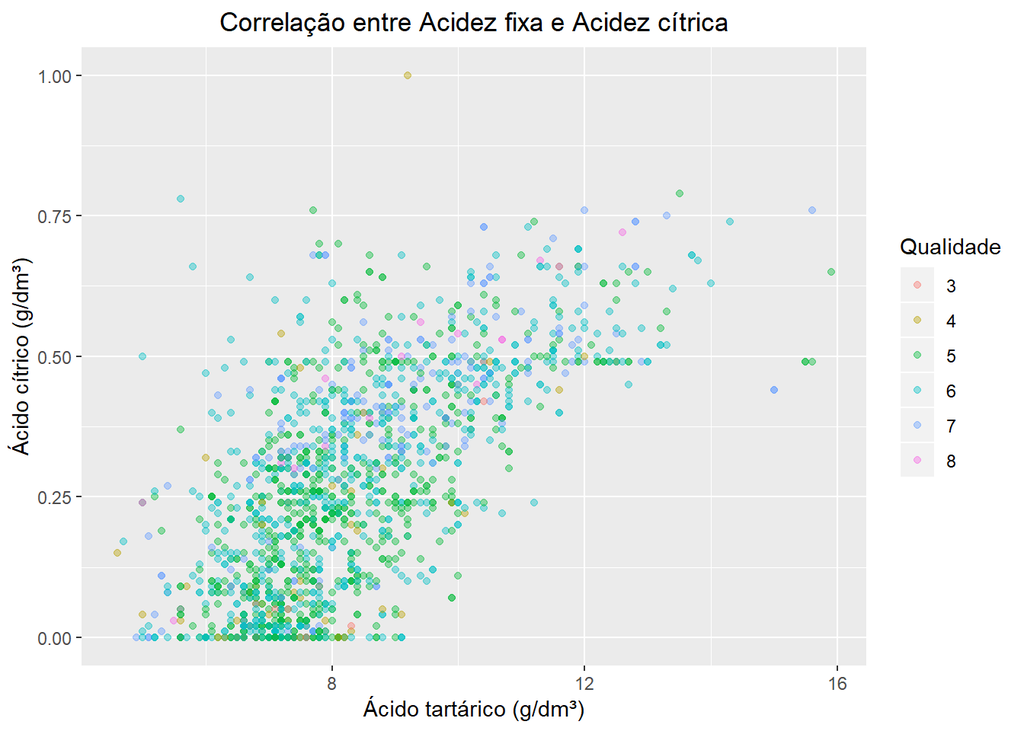

### Descrição do Terceiro Gráfico

Esse gráfico mostra a correlação entre Ácido cítrico (citric.acid) e Ácido tartárico (fixed.acidity) levando em consideração a qualidade do vinho (quality). O ácido cítrico é um dos atributos que mais possui correlação com a qualidade do vinho, e o ácido tartárico é o atributo que mais correlata com o ácido cítrico.

## Como pode ser visto no gráfico, é uma relação que possui uma lineraidade, porém os vinhos com uma maior qualidade não se concentram em uma parte do gráfico.

# Reflexão

O conjunto de dados de vinhos tintos possui 1599 análises, com onze atributos das características químicas do vinho. Comecei primeiramente explorando a dispersão dos atributos de maneira individual. Posteriormente foram feitas análises e gráficos analisando as variáveis de forma conjunta.

Algumas características impactam a qualidde do vinho, positivamente ou negativamente de maneira muito significativa, como o teor alcoolico, o ácido cítrico e o ácido acético. Entre essas características somente o ácido acético impacta negativamente a qualidade do vinho.

Uma surpresa ao analisar os dados foi descobrir que a quantidade de açúcar residual afeta muito pouco a qualidade do vinho, possuindo uma correlação de somente 0,01.

Os atributos dos dados possuem correlações entre si, e os dados são desbalanceados possuindo muito mais vinhos com notas medianas do que notas ruins ou ótimas. Portanto para uma predição ou classificação seria necessário tratar essas questões.